# Unidad 4. Estructura y estética de gráficos con ggplot2.

### layout

Esta opción ya la vimos anteriormente para los gráficos de supuestos. Básicamente se debe especificar una matriz mediante el comando `matrix` cuya estructura básica es:

```r
matrix(1:n, #cantidad de casilleros
       r,p) # distribución en filas y columnas
```

Entonces para una matriz 2*2 será:

```r
matrix(1:4,2,2)
```

Para una 3*4 será:

```r
matrix(1:12,3,4)
```

Por lo tanto, el comando de división gráfica tendrá la forma:

```r
layout(matrix(1:2,2,1))
Gráfico 1
Gráfico 2
layout(1) # al cerrar volvemos a establecer una ventana única
```

Se deben incluir tantos gráficos como particiones creadas. Por ejemplo viendo dos gráficos creados anteriormente:

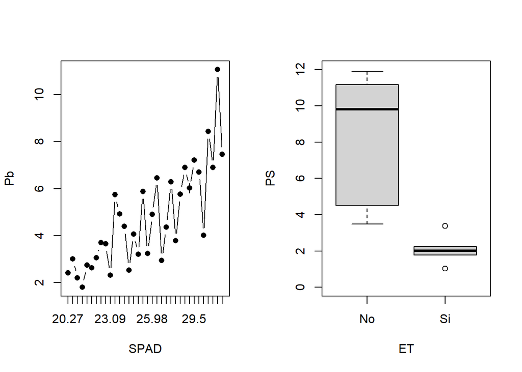

```r
# 1 fila y 2 columnas
layout(matrix(1:2,1,2))
lineplot.CI(x.factor = SPAD, response = Pb, data = HOJA)
boxplot(PS~ET, ylim = c(0,12),  data = SEM_Alim)
```

```r
layout(1)
```

Los parámetros `widths` y `heights` permite establecer uno más grande que el otro:

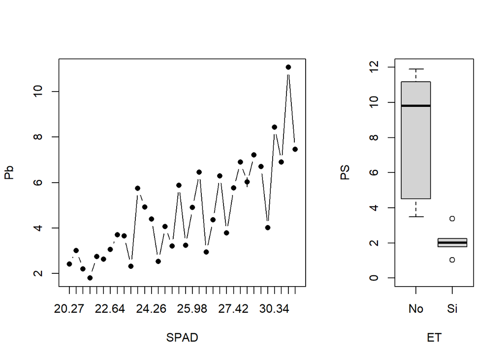

```r
layout(matrix(1:2,1,2), widths = c(2,1))
lineplot.CI(x.factor = SPAD, response = Pb, data = HOJA)
boxplot(PS~ET, ylim = c(0,12),  data = SEM_Alim)
```

```r
layout(1)
```

### par

La función `par` también nos permite dividir la ventana gráfica. Las opciones que ofrece son muchísimas, incluyendo opciones avanzadas del manejo de márgenes. Aquí solo la nombraremos brevemente, para obtener el mismo resultado mostrado anteriormente podemos hacer:

```r
par(mfrow = c(1, 2)) # filas y columnas
lineplot.CI(x.factor = SPAD, response = Pb, data = HOJA)
boxplot(PS~ET, ylim = c(0,12),  data = SEM_Alim)
par(mfrow = c(1, 1)) # volvemos a como estaba antes
```

Tanto la función `layout` como `par` son compatibles con *Devices* para la exportación.

### grid.arrange

Esta función se encuentra dentro del paquete **gridExtra** y nos permite subdividir la ventana gráfica en un entorno de ggplot2. Además, es enteramente compatible con `ggsave` para su exportación.

Su estructura general tiene la forma:

```r
grid.arrange(
  Grafico1 + modificaciones,
  Grafico2 + modificaciones,
  .....,
  ncol= número de columnas,
  nrow= número de filas,  # en general con establecer el número de columnas es suficiente
  widths=c(1,1,2), # podemos modificar el ancho relativo de cada columna
  heights=c(3,4,4) # lo mismo para las filas
)
```

Como los gráficos en ggplot suelen involucrar muchas líneas, es conveniente crear un objeto con cada gráfico a utilizar. Por ejemplo, podemos combinar los gráficos creados anteriormente:

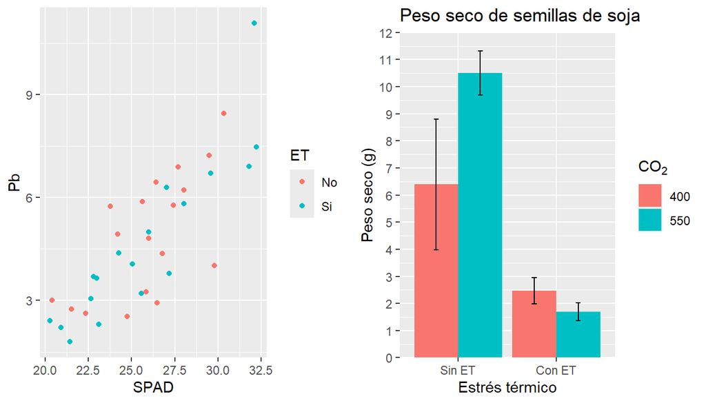

```r
grid.arrange(G2, G3, ncol=2)
```

Para exportar estos gráficos, hay que reemplazar en el mismo comando `ggsave` por todo el arreglo con `grid.arrange`.

### patchwork

El paquete **patchwork**[^2] permite una opción muy versátil para la combinación de gráficos y división de la ventana gráfica. Su uso además es muy sencillo, ya que si ya creamos los gráficos y tenemos el paquete cargado, podemos unir gráficos simplemente sumándolos:

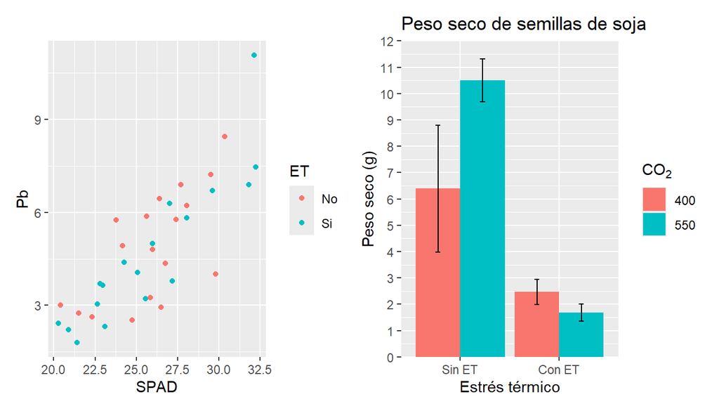

```r
G2 + G3
```

Existen diferentes combinaciones posibles, por ejemplo:

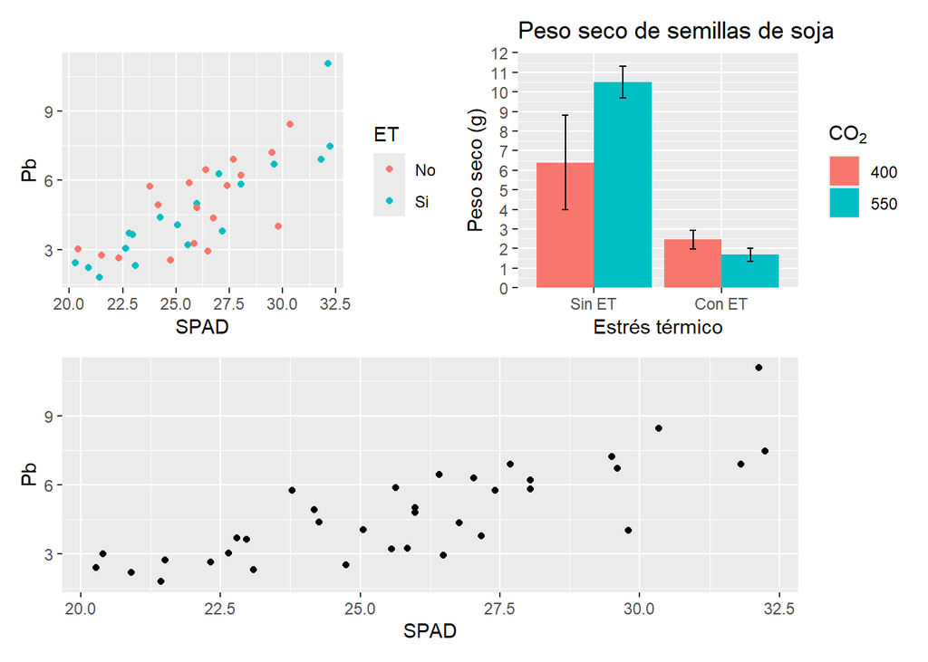

```r
(G2 + G3)/ G1
```

Dentro de este paquete se encuentra la función `wrap_plots` que acomoda correctamente los gráficos y alinea los ejes. Así podemos correr:

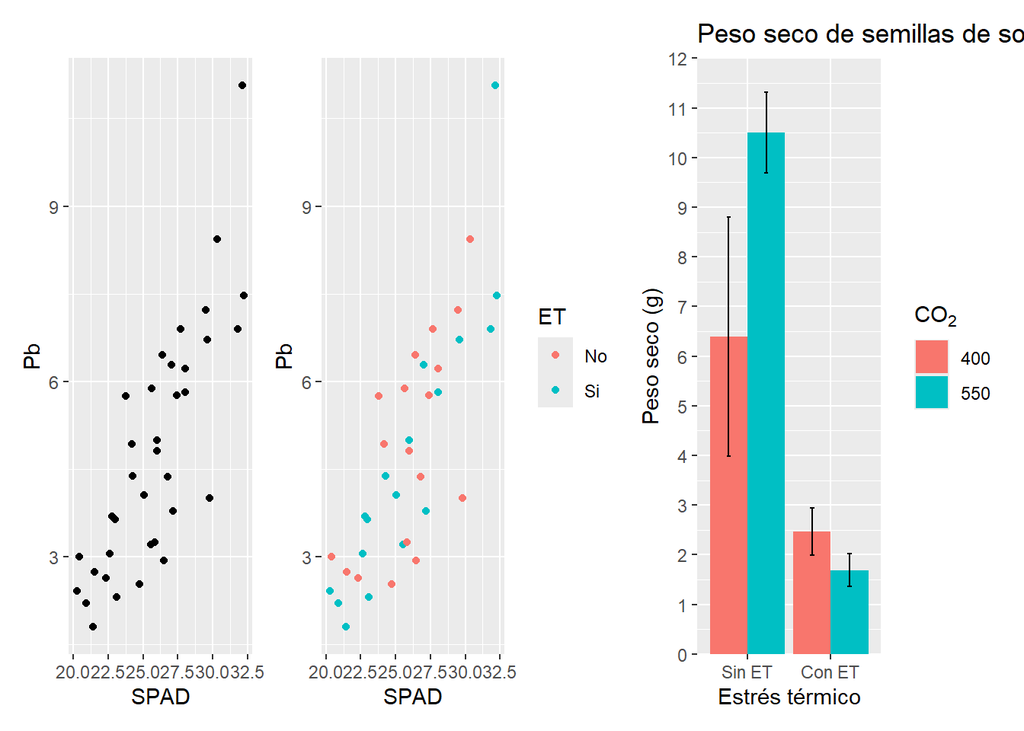

```r
wrap_plots(G1, G2, G3)
```

Podemos modificar la estructura del gráfico con la función `plot_layout` dentro de `wrap_plot`. Aquí podemos definir la estructura de filas y columnas, la posición de las leyendas (o agruparlas en algún sector). Por su parte, se pueden modificar e incluso automatizar anotaciones con `plot_annotation`. Por ejemplo modificando el agrupamiento anterior:

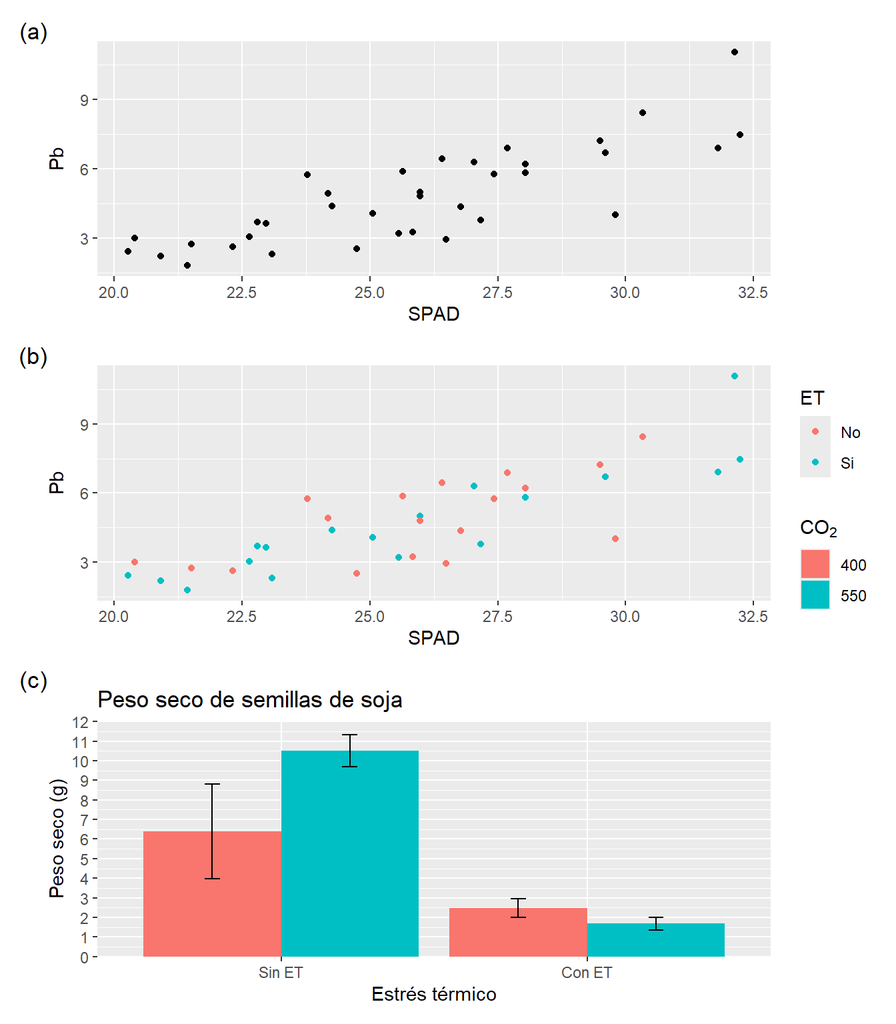

```r
wrap_plots(G1 + G2 + G3 +
             plot_layout(ncol = 1,
                         nrow = 3,
                         byrow = NULL,
                         guides = 'collect')) + # muestra las leyendas juntas
  plot_annotation(tag_levels = 'a', # establecemos el tipo de enumeración
                  tag_prefix = '(',
                  tag_suffix = ')')
```

Veremos más adelante algunas otras posibilidades con este paquete. Para exportar los gráficos se procede de igual manera que con cualquier otro gráfico de ggplot mediante la función `ggsave`.

También si los gráficos estuvieran combinados con **patchwork** podemos incluir la cuestión estética a todos a la vez al final separando con el comando &:

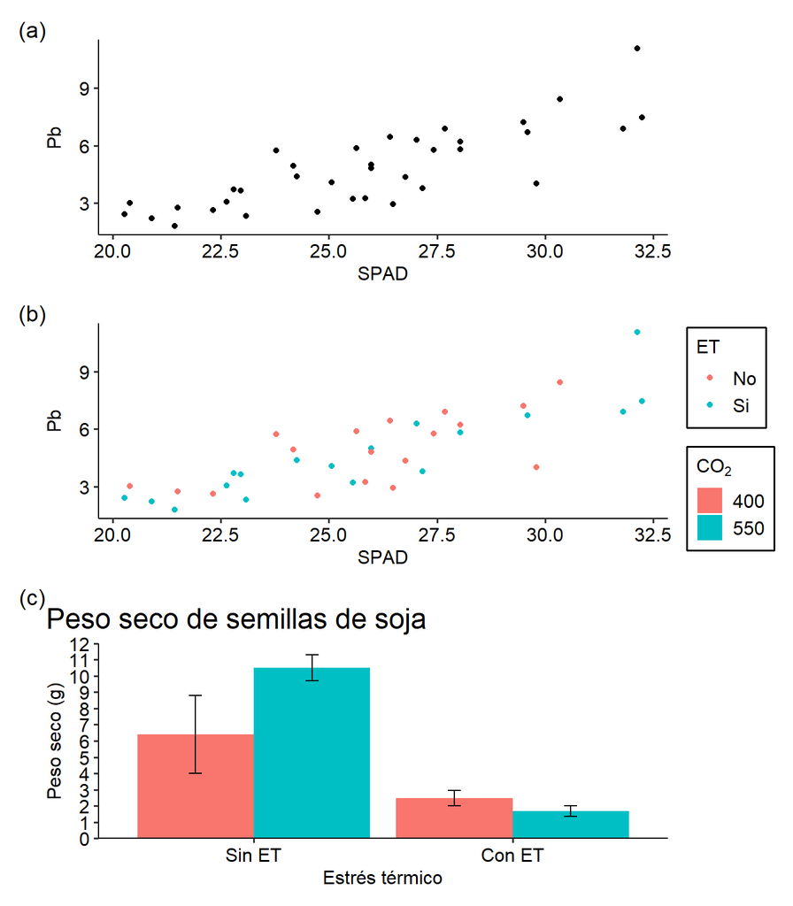

```r
wrap_plots(G1 + G2 + G3 +
             plot_layout(ncol = 1,
                         nrow = 3,
                         guides = 'collect')) +
  plot_annotation(tag_levels = 'a',
                  tag_prefix = '(',
                  tag_suffix = ')') &
  THEME
```

Si dos de los gráficos comparten el eje x (por ejemplo), puede ser de utilidad ocultar el título en uno de ellos, o incluso ocultar la escala en el eje. Esto se puede hacer de diferentes maneras, pero aquí les muestro una incluyendo el elemento vacío en el tema con *element_blank* :

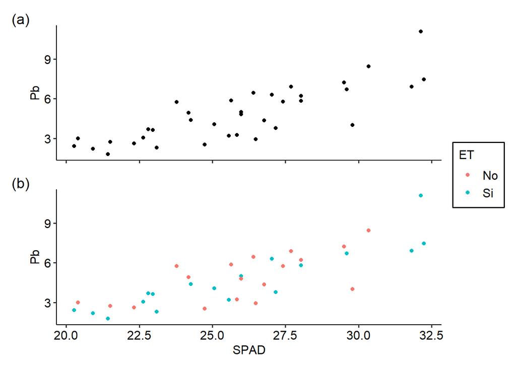

```r
wrap_plots(G1 + THEME +
             theme(axis.title.x = element_blank(),
                      axis.text.x = element_blank())+
          G2 + THEME +
             plot_layout(ncol = 1,
                         nrow = 2,
                         guides = 'collect')) +
  plot_annotation(tag_levels = 'a',
                  tag_prefix = '(',
                  tag_suffix = ')')
```

## Actividad 6

Exporte los dos gráficos que realizó en las actividades 3 y 5 combinados en una sola figura de dos columnas y una fila, agregue etiquetas a cada uno, aplique colores y escalas a los ejes. Junte las leyendas en una sola.

Volver al inicio

[^1]: Para más información del paquete *ggpubr* dirigirse a https://rpkgs.datanovia.com/ggpubr/ . Es un paquete muy interesante orientado a publicaciones usando ggplot2.
[^2]: Para más información acerca del uso de **patchwork** recomiendo la página https://patchwork.data-imaginist.com/index.html.